# Target Trial Emulation

Peirong Hao, Kevin Ying, Adam Bress, Tom Greene, Yizhe Xu

2026-03-24

# Introduction

Randomized controlled trials (RCTs) are the gold standard for evaluating medical interventions, but they are often impractical, slow, or costly. Modern causal inference methods, coupled with real-world data (RWD), provide a faster, well-powered approach to estimating treatment effects in diverse patient populations. Yet several barriers hinder their effective use in translational research. A key challenge is aligning “time zero,” the moment the cohort is defined, eligibility is assessed, and treatment strategies are assigned, which leads to intractable bias.

Target trial emulation (TTE) addresses these barriers by emulating RCT protocols with observational data, e.g., electronic health records (EHRs) (Hernán and Robins 2016; Hernán, Wang, and Leaf 2022). The TTE framework has proven especially useful in improving communication between statisticians and clinicians and better integrating clinical insight with sound study design and incisive data analysis to enhance the quality of research. High-quality observational studies built on TTE can complement findings from RCTs and provide actionable evidence (Wang et al. 2023).

This vignette shows how to build a fit-for-purpose dataset that minimizes bias. We briefly review the five key components of the TTE framework and explain why clear definitions for each are essential.

## Eligibility Criteria

- Both inclusion and exclusion criteria need to be defined using **only information prior to or at baseline**
- Eligibility criteria that use post-baseline information induce **selection bias**
- Not all trials of interest can be emulated using observational data. TTE is only feasible when the observational data contains all the information needed to apply the pre-defined eligibility criteria

## Treatment Strategies

- Observational data is best used to emulate **a pragmatic trial** in the sense that
  - Open-label design: patients are aware of the treatment they are prescribed
  - Treatments are compared under the usual conditions used
  - Cannot compare new treatment due to lack of data
- New user design is highly recommended to avoid **prevalent user bias**
  - Treatment of interest: Hormone therapy versus no treatment (Hernán and Robins 2016)
  - Given that hormone therapy may cause a short-term increase in the risk of coronary heart disease (CHD), current users are likely to be CHD free
  - Including current users in the study cohort may introduce bias since patients who initiated hormone therapy then switched due to side effects are not included
  - Prevalent user bias is a type of selection bias
- Benefits of using active control
  - Treatment of interest: ACEI versus ARB
  - Both medications are first-line antihypertensive medications that are prescribed interchangeably by physicians
  - Thus, patients in these two treatment groups are much more similar, which leads to smaller confounding by indication bias before any adjustment. We refer to this situation as **pseudo-randomization**
  - In contrast, in the example of hormone therapy versus no treatment, patients who use hormone therapy can be very different than those who do not use the therapy in terms of socioeconomic status and body mass index

## Assignment Procedures

- It is infeasible to emulate trials with blind assignment as individuals are aware of the treatment they received in observational data
- To mimic the randomized treatment assignment in RCTs, we restore comparability between treatment groups within strata defined by baseline covariates, and we refer to this as **conditional exchangeability**
- To achieve conditional exchangeability, we need to adjust for all confounding covariates using causal inference methods (see (Miguel; Robins 2020) for more details)

## Outcome Identification and Validation

- Outcomes can be identified using International Classification of Disease (ICD) codes (Version 9 or 10), medication use, or natural language processing of clinical notes
- It is challenging to conduct blind outcome ascertainment in observational data since healthcare providers are often aware of the treatment a patient received
- Death outcome is an exception as it can be independently ascertained by death registry

## Time Zero

- This is the most important component in TTE
- Time zero is the start of follow-up, also referred to as baseline
- In RCTs, the time of treatment assignment (A), the time of meeting eligibility criteria (E), and the start of follow-up ($T_0$) are typically well aligned. This alignment helps to reduce **selection bias** and **immortal time bias** significantly
- Check out the four classic emulation failure modes below (Hernán et al. 2016)

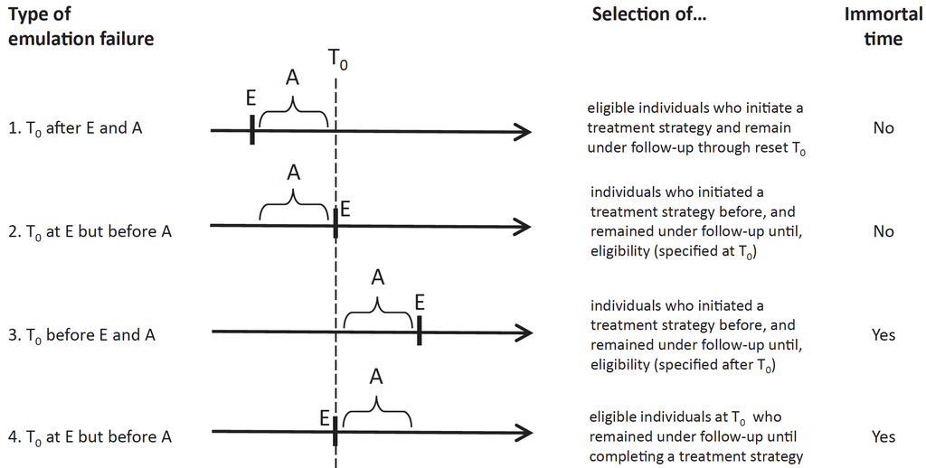

# Implementation of TTE framework

## An Active-comparator Design

Suppose we are interested in comparing the effectiveness of ARB versus ACEI anti-hypertensive medications on reducing the risk of cardiovascular disease (CVD).

- **Step 1: Clearly define the research questions of interest**. In our case, they are:
  - Primary: What is the effect of initiating ARBs versus ACEIs on CVD risk?
  - Secondary: What is the effect of initiating and continuously using ARBs versus ACEIs on CVD risk?
  - *Vaguely defined questions are troublesome as they impact the study design, data preparation, and analysis methods used to answer these questions, leading to biased and misleading findings.
- **Step 2: Clarify study design**
  - Our example uses an observational, new-user, active comparator, retrospective cohort design. Thanks to the active-comparator design, the time zero for both treatment groups is straightforward, that is, the time of initiating ARBs or ACEIs. Therefore, we only need to **emulate a single trial**
  - In contrast, in a placebo-control design, subjects in the control group may meet the eligibility criteria multiple times, so **emulating a sequence of trials** may be needed especially with a small sample size or low event rate. We will explain how to implement TTE for [a placebo-control design](https://uqualitycausal.github.io/TTECausalR/TTEdemoSeq.html) using the *TrialEmulation* R package (Danaei et al. 2013)
- **Step 3: Build a data set that fits the purpose of the study**
  - A data set can be used to answer these questions with minimal bias
  - It is a false belief that one data set can be used to answer any questions.
  - To build a fit-for-purpose dataset, we demonstrate how to implement TTE framework with observational data through manual coding.

Before we begin, we import a simulated observational dataset representing patients with hypertension who are followed over time to compare the risk of incident cardiovascular disease (CVD) under ACEI versus ARB treatment. The dataset includes baseline covariates, time-varying covariates, treatment, and outcome indicators, allowing us to demonstrate the implementation of TTE and causal inference methods in a realistic longitudinal setting. For details on data-generating mechanism and parameter settings, please refer to the [data simulation function](https://github.com/UQualityCausal/TargetTrialEmulation/blob/main/generateObsData.R).

```r
# Load data
obsdata <- readRDS("obsdata2trt.rds")

# Function to extract variable label
get_label <- function(x) {
  lbl <- attr(x, "label", exact = TRUE)
  if (is.null(lbl)) "" else as.character(lbl)
}

# Create data dictionary
dict <- data.frame(
  Variable = names(obsdata),
  Meaning  = vapply(obsdata, get_label, character(1)),
  check.names = FALSE
)

# Present data dictionary
knitr::kable(dict, caption = "Data Dictionary", row.names = FALSE)
```

Data Dictionary

| Variable | Meaning |
| --- | --- |
| id | Patient ID |
| time | Time index for longitudinal records (months) |
| X1 | Non-ACEI or ARB antihypertensive medication use over time |
| X2 | Standardized systolic blood pressure over time |
| X3 | Biological sex (M=1, F=0) |
| X4 | Standardized diastolic blood pressure at baseline |
| age | Age over time (years) |
| A | Treatment indicator over time (ARB = 1, ACEI = 0; NA = neither) |
| Y | Event indicator of cardiovascular disease |
| C | Indicator of early dropout / censoring |

## Write your own code to implement TTE

**Table 1** shows the protocol of the target trial that I wish to run and my emulating plan with observational data side by side

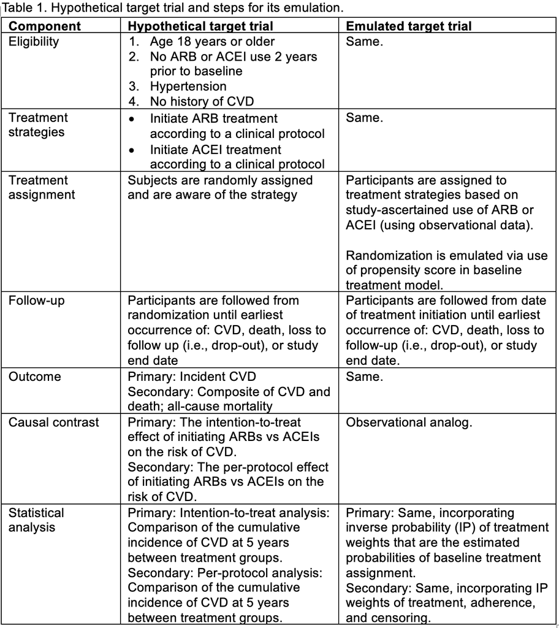

**Component 1: Time 0: the time point a subject satisfies the eligibility criteria and initiates treatment**

- Patients without hypertension and with CVD are already excluded from our observational data in another pre-processing step
- We apply the rest of eligibility criteria (the first two) in Table 1 to our data and create an “eligible” indicator

```r
obsdata1 <- obsdata %>%
  group_by(id) %>%
  mutate(eligible = as.integer(age >= 50 & cumsum(Y) == 0 & (slide_dbl(
    is.na(A),
    sum,
    .before = 24, # Look back 24 rows
    .after = -1, # Exclude the current row
    .complete = T
  ) >= 24))) %>% # Age over 50, no history of CVD, and no ACEI or ARB treatment in last 24 months.
  mutate(eligible = ifelse(is.na(eligible), 0, eligible)) %>% # If unknown, then not eligible
  ungroup()
```

Let us see when Subject 24 becomes eligible: - Subject 24 is not eligible from time 2001-03-01 to 2002-06-01 due to age below 50. He is still not eligible until 2003-03-01 when he has enough records to show that he did not receive ACEI or ARB treatment in the last 24 months.

```r
obsdata1 %>% filter(id == 24)
```

```
#> # A tibble: 42 × 11
#>       id time          X1     X2    X3    X4   age     A     Y     C eligible
#>    <dbl> <date>     <dbl>  <dbl> <dbl> <dbl> <dbl> <dbl> <dbl> <dbl>    <dbl>
#>  1    24 2001-03-01     1 -1.41      1 0.512  48.7    NA     0     0        0
#>  2    24 2001-04-01     1 -0.403     1 0.512  48.8    NA     0     0        0
#>  3    24 2001-05-01     1 -0.244     1 0.512  48.8    NA     0     0        0
#>  4    24 2001-06-01     1  0.112     1 0.512  48.9    NA     0     0        0
#>  5    24 2001-07-01     1 -0.283     1 0.512  49.0    NA     0     0        0
#>  6    24 2001-08-01     0  0.669     1 0.512  49.1    NA     0     0        0
#>  7    24 2001-09-01     1 -0.983     1 0.512  49.2    NA     0     0        0
#>  8    24 2001-10-01     1  0.676     1 0.512  49.3    NA     0     0        0
#>  9    24 2001-11-01     0 -0.752     1 0.512  49.3    NA     0     0        0
#> 10    24 2001-12-01     1  0.412     1 0.512  49.4    NA     0     0        0
#> # ℹ 32 more rows
```

Next, we identify time 0 ($T_0$) at which a subject becomes eligible and initiates a treatment.

```r
time0 <- obsdata1 %>% filter(eligible == 1 & !is.na(A)) %>%
  group_by(id) %>%
  summarise(
    t0 = min(time)) %>%
  ungroup()
```

Check the number of subjects enrolled in analysis.

```r
nrow(time0)
```

```
#> [1] 995
```

Let’s verify one example. Subject 24 first becomes eligible at time 2003-03-01, and he initiates treatment at time 2004-05-01. So ($T_0$) is 2004-05-01 for him.

```r
time0 %>% filter(id == 24)
```

```
#> # A tibble: 1 × 2
#>      id t0
#>   <dbl> <date>
#> 1    24 2004-05-01
```

```r
obsdata1 %>% filter(id == 24)
```

```
#> # A tibble: 42 × 11
#>       id time          X1     X2    X3    X4   age     A     Y     C eligible
#>    <dbl> <date>     <dbl>  <dbl> <dbl> <dbl> <dbl> <dbl> <dbl> <dbl>    <dbl>
#>  1    24 2001-03-01     1 -1.41      1 0.512  48.7    NA     0     0        0
#>  2    24 2001-04-01     1 -0.403     1 0.512  48.8    NA     0     0        0
#>  3    24 2001-05-01     1 -0.244     1 0.512  48.8    NA     0     0        0
#>  4    24 2001-06-01     1  0.112     1 0.512  48.9    NA     0     0        0
#>  5    24 2001-07-01     1 -0.283     1 0.512  49.0    NA     0     0        0
#>  6    24 2001-08-01     0  0.669     1 0.512  49.1    NA     0     0        0
#>  7    24 2001-09-01     1 -0.983     1 0.512  49.2    NA     0     0        0
#>  8    24 2001-10-01     1  0.676     1 0.512  49.3    NA     0     0        0
#>  9    24 2001-11-01     0 -0.752     1 0.512  49.3    NA     0     0        0
#> 10    24 2001-12-01     1  0.412     1 0.512  49.4    NA     0     0        0
#> # ℹ 32 more rows
```

Filter out ineligible subjects

```r
obsdata2 <- obsdata1 %>%
  left_join(time0, by = "id") # Merge the eligibility information to our observational data
attr(obsdata2$eligible, "label") <- "Eligibility indicator at each time in records"
attr(obsdata2$t0, "label") <- "Start of follow-up"

obsdata3 <- obsdata2 %>%
  filter(time >= (t0 - 31)) # Include only eligible subjects who initiates treatment and previous month to get the baseline

# Check every subject has exactly one month of data before time 0
obsdata3 %>% filter(time < t0) %>% group_by(id) %>% summarise(n = n()) %>% filter(n != 1) # expect 0 rows
```

```
#> # A tibble: 0 × 2
#> # ℹ 2 variables: id <dbl>, n <int>
```

**Component 2: Treatment strategies**

- We group patients into ARB or ACEI initiators based on their outpatient pharmacy dispense
- ARB initiators are coded as 1 and ACEI initiators are coded as 0 in our data (code is not shown)
- Individuals who initiated both ARB and ACEI medications are excluded

**Component 3: Treatment assignment**

- Although ARBs and ACEIs are both first-line treatment and used interchangeably at clinic, they are not completely randomized to patients in our observational data, which may lead to imbalance in patient characteristics between treatment groups
- It is perhaps more plausible to consider ARB or ACEI medications are randomized among patients with the same age, sex, blood pressure, and other antihypertensive medication use
- Formally, we assume treatment assignment is independent of the CVD outcome conditional on all the baseline covariates mentioned above, i.e., conditional exchangeability assumption
- We mostly worry about the baseline covariates that impact treatment assignment and outcome and they are called **confounders**
- The conditional exchangeability assumption becomes more plausible as more confounders are measured and considered though we can never verify the assumption completely holds true
- We will demonstrate how to restore the conditional exchangeability using causal inference methods in the tutorial of [Intention-to-treat Analysis](https://uqualitycausal.github.io/TTECausalR/IntentionToTreat.html).

**Components 4 & 5: Follow-up and Outcome**

```r
obsdata4 <- obsdata3 %>% filter(t0 >= as.Date("2001-01-01") & t0 < as.Date("2004-01-01") & time < as.Date("2008-01-01")) %>%
  mutate(follow_up = as.integer(time - t0)) %>%
  select(-t0, -eligible)
```

Finally, we save the data for downstream statistical analysis

```r
# Extract baseline data: last follow-up < 0 for each id
baseline <- obsdata4 %>%
  filter(follow_up < 0) %>%
  group_by(id) %>%
  slice_max(order_by = follow_up, n = 1, with_ties = FALSE) %>%  # Closest to 0 from below
  ungroup() %>%
  select(id, X1, X2, age) %>%
  rename(
    X1_0  = X1,
    X2_0  = X2,
    age_0 = age
  ) # The baseline values are the values of the month before treatment initiation.

assigned.trt <- obsdata4 %>%
  filter(follow_up == 0) %>%
  select(id, A) %>%
  rename(assigned_treatment = A) # The assigned treatment is the treatment at initiation.

baseline <- baseline %>%
  left_join(assigned.trt, by = "id") %>%
  select(id, assigned_treatment, everything())

# Merge baseline data to longitudinal data
obsdata5 <- obsdata4 %>%
  left_join(baseline, by = "id") %>%
  filter(follow_up >= 0) %>%
  arrange(id, follow_up)
attr(obsdata5$X1_0, "label") <- "Baseline value of X1"
attr(obsdata5$X2_0, "label") <- "Baseline value of X2"
attr(obsdata5$age_0, "label") <- "Baseline value of age"
attr(obsdata5$follow_up, "label") <- "Follow-up time"
obsdata5 %>% slice_head(n = 10)
```

```
#> # A tibble: 10 × 15
#>       id time          X1     X2    X3    X4   age     A     Y     C follow_up
#>    <dbl> <date>     <dbl>  <dbl> <dbl> <dbl> <dbl> <dbl> <dbl> <dbl>     <int>
#>  1     5 2003-04-01     1 -2.95      0 0.604  81.3     0     0     0         0
#>  2     5 2003-05-01     1 -1.67      0 0.604  81.3     0     0     0        30
#>  3     5 2003-06-01     0  0.163     0 0.604  81.4     0     0     0        61
#>  4     5 2003-07-01     0  0.638     0 0.604  81.5     0     0     0        91
#>  5     5 2003-08-01     0  2.27      0 0.604  81.6     0     0     0       122
#>  6     5 2003-09-01     0  1.75      0 0.604  81.7     0     0     0       153
#>  7     5 2003-10-01     0  0.331     0 0.604  81.8     0     0     0       183
#>  8     5 2003-11-01     0 -1.04      0 0.604  81.8     0     0     0       214
#>  9     5 2003-12-01     1 -0.324     0 0.604  81.9     0     0     0       244
#> 10     5 2004-01-01     0  1.04      0 0.604  82.0     0     0     0       275
#> # ℹ 4 more variables: assigned_treatment <dbl>, X1_0 <dbl>, X2_0 <dbl>,
#> #   age_0 <dbl>
```

```r
# Save the data
saveRDS(obsdata5, "obsdata5.rds")
```

## Funding

The research reported in this publication was supported in part by the National Center for Advancing Translational Sciences of the National Institutes of Health under Award Number UM1 TR 004409. The content is solely the responsibility of the authors and does not necessarily represent the official views of the National Institutes of Health.

## References

Danaei, Goodarz, Luis A García Rodríguez, Oscar Fernández Cantero, Roger Logan, and Miguel A Hernán. 2013. “Observational Data for Comparative Effectiveness Research: An Emulation of Randomised Trials of Statins and Primary Prevention of Coronary Heart Disease.” *Statistical Methods in Medical Research* 22 (February): 70–96. https://doi.org/10.1177/0962280211403603.

Hernán, Miguel A, and James M Robins. 2016. “Using Big Data to Emulate a Target Trial When a Randomized Trial Is Not Available.” *American Journal of Epidemiology* 183: 758–64.

Hernán, Miguel A, Brian C Sauer, Sonia Hernández-Dĺaz, Robert Platt, and Ian Shrier. 2016. “Specifying a Target Trial Prevents Immortal Time Bias and Other Self-Inflicted Injuries in Observational Analyses.” *Journal of Clinical Epidemiology* 79: 70–75.

Hernán, Miguel A, Wei Wang, and David E Leaf. 2022. “Target Trial Emulation: A Framework for Causal Inference from Observational Data.” *JAMA* 328 (24): 2446–47.

Miguel; Robins, James Hernan. 2020. *Causal Inference: What If.* Boca Ration: Chapman & Hall/CRC.

Wang, Shirley V, Sebastian Schneeweiss, Jessica M Franklin, Rishi J Desai, William Feldman, Elizabeth M Garry, Robert J Glynn, et al. 2023. “Emulation of Randomized Clinical Trials with Nonrandomized Database Analyses: Results of 32 Clinical Trials.” *Jama* 329: 1376–85.